# Skagit Steelhead Fishery Management 2021

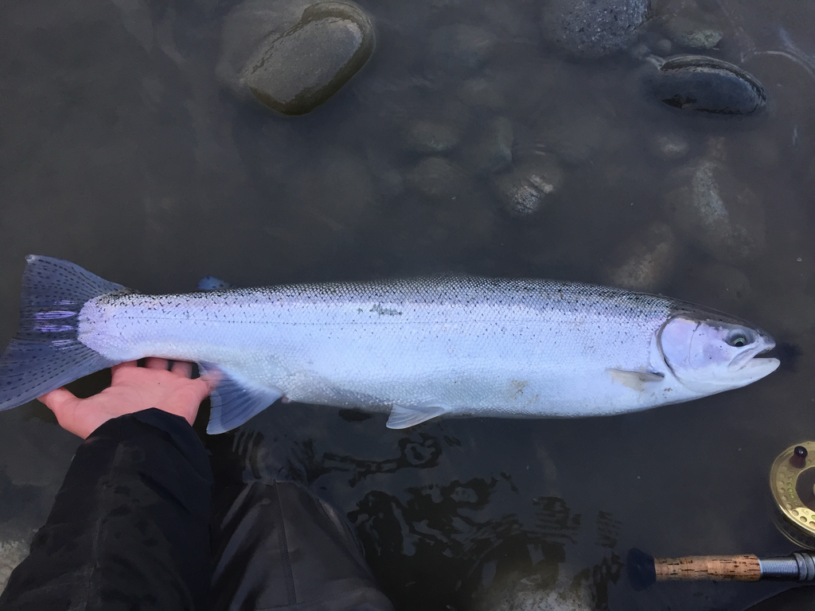

## Overview

WDFW re-opened a popular sport fishery for winter steelhead on the Skagit River after a decade-long closure following the Endangered Species Act (ESA) listing of Puget Sound steelhead as Threatened in 2007. A [**Resource Management Plan**](https://github.com/tbuehrens/CreelAnalysis/blob/main/background/final_skagit_rmp_erd_04-10-2018.pdf) (RMP) that was jointly developed by WDFW and tribal co-managers, and adopted by NOAA Fisheries, provides the legal basis and rule set governing this fishery under the ESA. The plan ensures that impacts to wild steelhead populations from sport and tribal fisheries will not prevent the population from achieving conservation and recovery goals. The plan calls for careful monitoring of wild steelhead mortality resulting from fisheries in order to ensure that total mortality rate limits specified in the plan are not exceeded. Although current sport fishery regulations require release of wild steelhead, mortality does occur as a result of fish being caught and released, and these impacts must be quantified.

This page provides documentation of WDFW’s efforts to plan and administer a fishery for Skagit steelhead that is consistent with the RMP, including:

1. a comparison of the pre-season planned Skagit steelhead sport fishery-induced wild steelhead mortality with allowable exploitation rates designated in the Skagit steelhead RMP.
2. in-season tracking of Skagit steelhead sport fishery fishery-induced wild steelhead mortality relative to allowable exploitation rates designated in the Skagit steelhead RMP.

Want to see the data and analysis for yourself? If you are interested in running the analysis yourself, jump to the “Reproducing the Analysis” section below, which overviews the GitHub code repository that contains the code necessary to reproduce the Skagit steelhead fishery creel analysis and fishery impact monitoring for 2021, and to reproduce this page.

## Pre-season Fishery Planning

This section displays the pre-season Skagit wild winter steelhead run-size forecast, the exploitation rate matrix prescribed by the Resource Management Plan, and uses the two to calculate the allowable harvest. It then compares the planned harvest (sport fishery catch * assumed catch and release mortality rate) with the allowable harvest to estimate the percent of the allowable harvest the sport fishery will use as well as the probability that the sport fishery will exceed various percentages of the allowable impacts.

First, the allowable harvest rates in the RMP are:

Table 1. Allowable Harvest Rates, Skagit RMP

| Minimum Run Size | Maximum Run Size | Exploitation Rate |
| --- | --- | --- |
| 0 | 4000 | 0.04 |
| 4001 | 6000 | 0.10 |
| 6001 | 8000 | 0.20 |
| 8001 | 1000000 | 0.25 |

The run size forecast is below, and is reprinted from the co-manager agreed-to [**pre-season forecast**](https://github.com/tbuehrens/Skagit-River-Steelhead-Forecast/blob/master/analysis/App_2_Model_fitting_forecast_2020_2021_step_head_fcst.pdf). A published scientific paper describing the methods may be found here: [**(preseason forecast publication)**](https://besjournals.onlinelibrary.wiley.com/doi/abs/10.1111/1365-2664.13789).

For more details on how this forecast was developed, see this [**GitHub repository**](https://github.com/casruff/Skagit-River-Steelhead-Forecast), which is collaboratively maintained by tribal Co-Managers & WDFW.

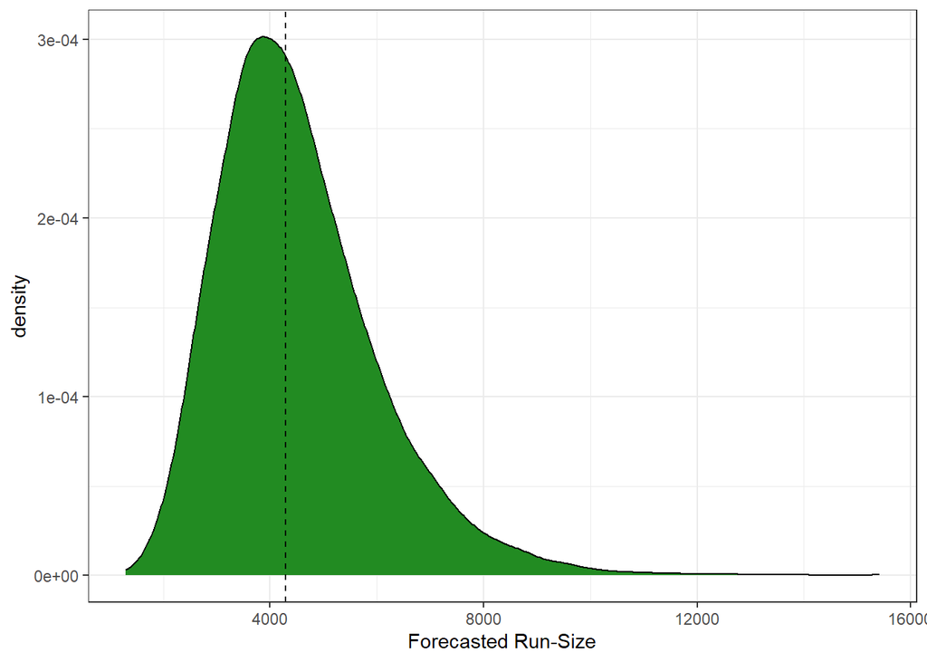

Figure 1. Skagit Steelhead Run-size Forecast. The forecast is shown as a ‘bell curve’ (though not symmetric), where the height of the curve is proportional to the probability that the true value (catch or effort) is equal to a particular value on the x-axis. The ‘best’ value is the 50th percentile, shown as a dashed line.

Table 2. Runsize Forecast. The ‘best’ estimate is the median or 50th percentile. The table shows the forecast percentiles, which represent the probability that the true run-size will fall below a particular value. For example, there is a 50% probability the true run size will be below the 50th percentile of the forecast.

| Run Size | Percentile |
| --- | --- |
| 2283 | 2.5 |
| 3470 | 25.0 |
| 4297 | 50.0 |
| 5322 | 75.0 |
| 8166 | 97.5 |

### Fishery Impacts Relative to Resource Management Plan Limits: Preseason Plan

Below you will find a comparison of the the planned sport fishery catch, assuming 10 percent catch and release mortality, with the allowable harvest based on the run size forecast and the RMP mortality limits.

The allowable harvest, according to the RMP, is the number of fish that may be killed by the combined sport and tribal fisheries. However, as seen above, this number depends on the run-size, which fishery managers will not know until after the fishing season when they estimate escapement. However, based on the pre-season forecast run size, we can estimate what the true allowable harvest will be by combining the forecast run size, including its uncertainty, with the harvest rate matrix prescribed by the RMP. We can then plot the probability that the true allowable harvest will exceed a range of values. The true allowable harvest will be known with more certainty after the season when the actual run-size is known and the appropriate harvest rate from the matrix can be multiplied by the actual run size.

For example, in 2021 there is a greater than 90 percent chance that the true allowable harvest based on the true run size and the harvest matrix, will exceed 100 fish. There is a 50% chance that the allowable harvest will exceed 430 fish (10 percent of the best estimate of the run-size from the forecast), and a very small chance the allowable harvest will be greater than 2,000 fish:

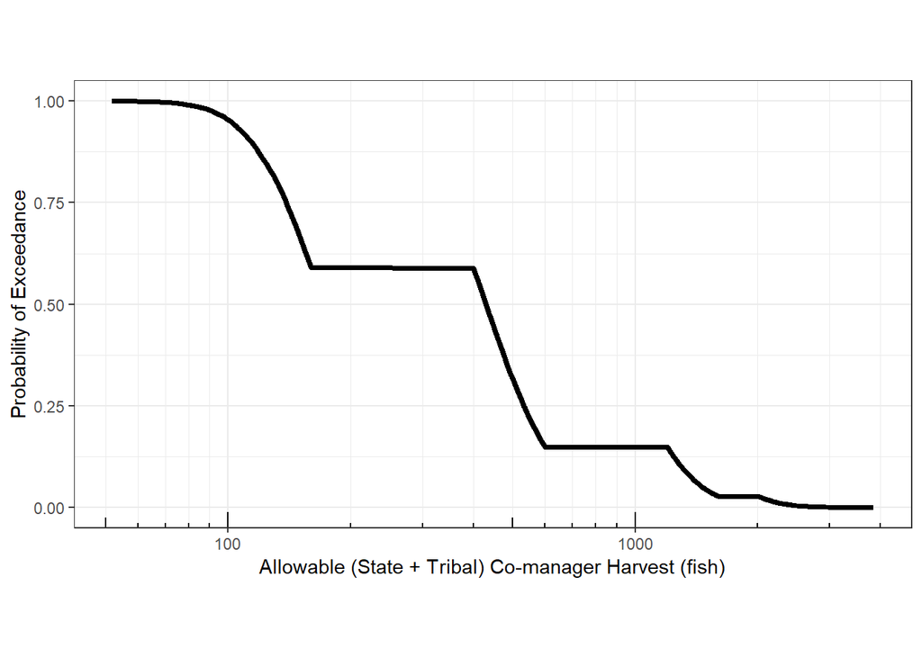

Figure 2. Probability that the allowable harvest exceeds a particular number of fish based on the RMP. Note the log10 scale on the x-axis.

Given the uncertainty in what the allowable harvest will turn out to be, managers must balance the risk of exceeding the allowable harvest with the cost of erring so heavily on the side of conservation (to ensure the allowable harvest is not exceeded) that no fishery is allowed at all. To assist with this task, managers can plan a fishery to harvest a particular number of fish (which itself may be estimated with uncertainty) and then calculate the probability that the allowable harvest will turn out to have been exceeded if the planned fishery is implemented.

For example, in 2021, a four-day a week fishery was planned with a projected total harvest of 76 fish (760 wild fish handled * assumed 10 percent catch and release mortality rate). If the actual catch matches the projection exactly, this would translate to 18 percent of the allowable (sport and tribal) harvest under the RMP if the true allowable harvest is 430 (which is the best estimate from the preseason forecast, and corresponds to the 50% exceedance probability).

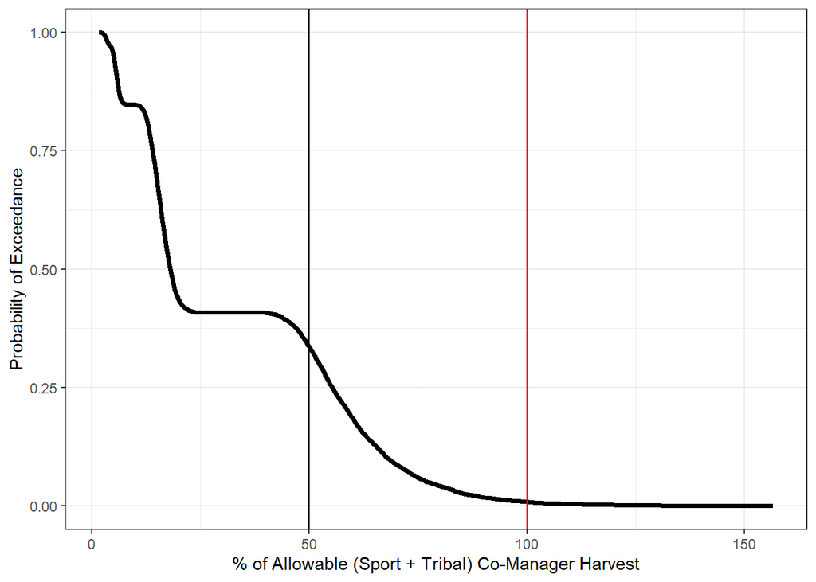

Figure 3. Probability that the pre-season planned sport fishery harvest exceeds the allowable harvest (expressed as percentages) under the RMP. Vertical lines denote 50 percent of the allowable harvest, which is shared between the state and tribes, and 100 percent of the allowable harvest. The best estimate of the percent of the allowable harvest that will be used by the sport fishery is located on the graph where the probability of exceedance is 50 percent.

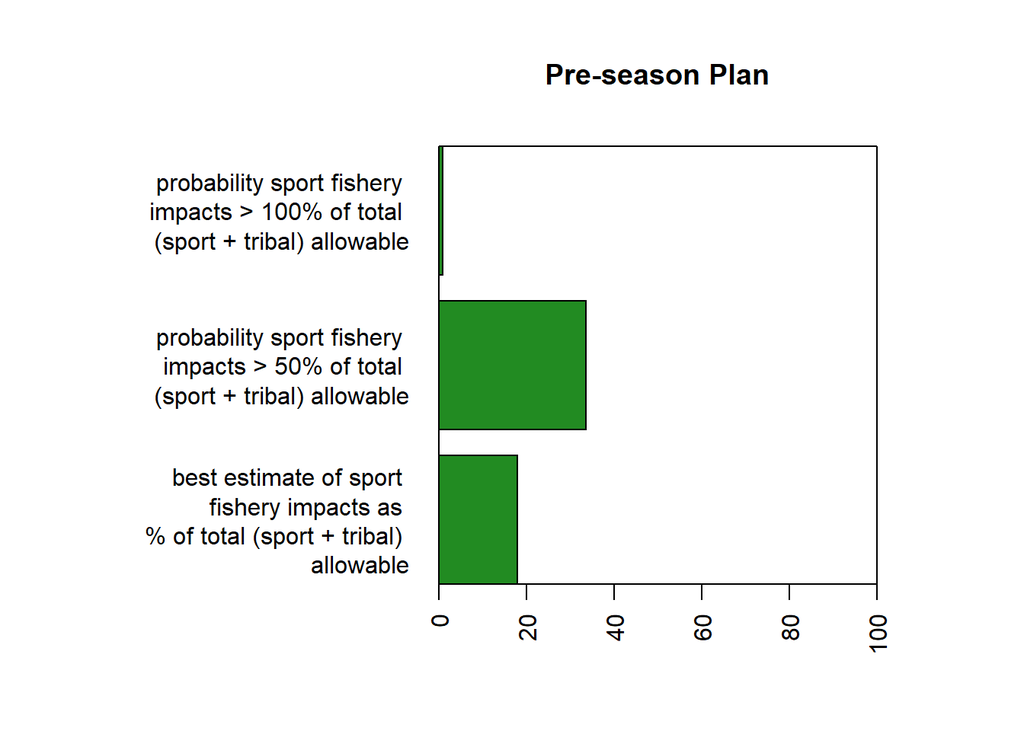

Figure 4. Pre-season Planned Probability that the sport fishery harvest exceeds 50 and 100 percent of the allowable harvest under the RMP, as well as the best estimate of the percentage of allowable impacts the sport fishery will use

## In-season Fishery Results

WDFW fishery managers use data from creel surveys to estimate the season total and daily catch and effort, and the daily catch per unit effort (CPUE). Results presented below include data collected through: **04/13/2021**

### Disclaimer

Contents on this page should be treated as preliminary and are subject to change. While every effort has been made to ensure the accuracy of data and modeling here, some numbers may change. Particularly in-season catch and effort estimates may change as additional data becomes available, and as data errors are corrected.

### Season Total Effort and Catch

This table and the figures below it show estimates of the season total catch and effort. Estimates are shown as ‘bell curves’ (though not symmetric), where the height of the curve is proportional to the probability that the true value (catch or effort) is equal to a particular value on the x-axis. The “best” estimate is the 50th percentile (median) in the table, and is denoted by the middle dashed line in the graphs:

Table 3. Total Catch (fish) and Effort (hours). The ‘best’ estimate is the median or 50th percentile. The table shows the percentiles of estimated catch and effort, which represent the probability that the true catch or effort is below a particular value. For example, there is a 50% probability the true catch is below the 50th percentile of the estimated catch in this table.

| Variable | Mean | 2.5% | 25% | 50% | 75% | 97.5% |
| --- | --- | --- | --- | --- | --- | --- |
| Total_season_catch | 762 | 683 | 731 | 758 | 789 | 857 |
| Total_season_effort | 28225 | 26189 | 27452 | 28177 | 28940 | 30578 |

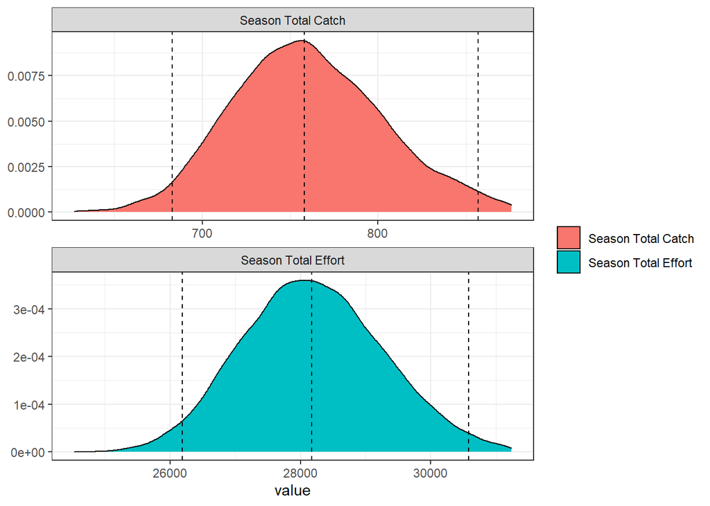

Figure 5. Season total catch (fish) and effort (angler hours). The middle dashed line shows the posterior median or ‘best’ estimate. Outer dashed lines show 95 percent credible intervals.

### Daily Catch, Effort, and Catch Per Unit Effort

Below, you will find an estimate of the daily catch (fish), effort (hours), and catch per unit effort (fish/hr). The lines are the “best” estimates and the shading shows the 95 percent credible intervals (which are obtained from the statistical model used to estimate catch).

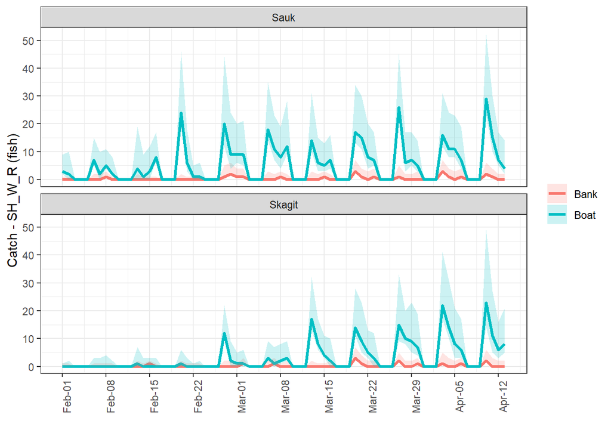

Figure 6. Daily catch. Lines are posterior medians or ‘best’ estimates, while shading shows 95% credible intervals.

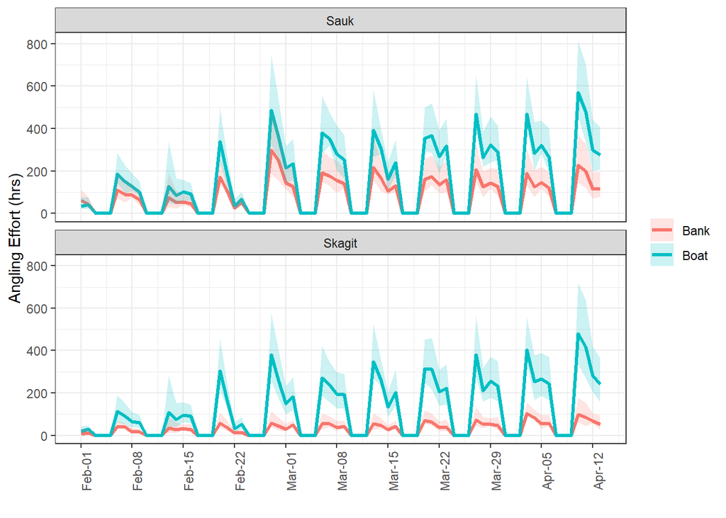

Figure 7. Daily effort. Lines are posterior medians or ‘best’ estimates, while shading shows 95% credible intervals.

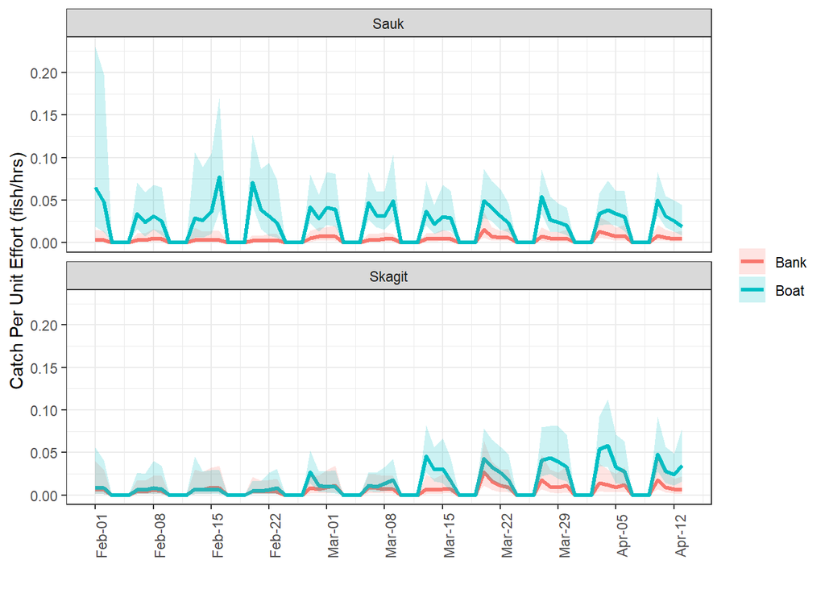

Figure 8. Daily CPUE. Lines are posterior medians or ‘best’ estimates, while shading shows 95% credible intervals.

### In-season Impact Monitoring: Fishery Impacts Relative to Resource Management Plan Limits

Here, we compare the actual in-season estimated sport fishery catch, assuming 10% C&R mortality, with the allowable harvest estimated from the forecasted run size and the RMP mortality limits, to estimate the probability that the allowable harvest has been exceeded by the actual fishery (as opposed to the pre-season plan that we looked at previously). Early in the season when little catch has occurred, the probability that the allowable harvest has been exceeded is low, but increases as the season goes on. This analyis enables an in-season quantification of risk by managers, which may be helpful in decision-making:

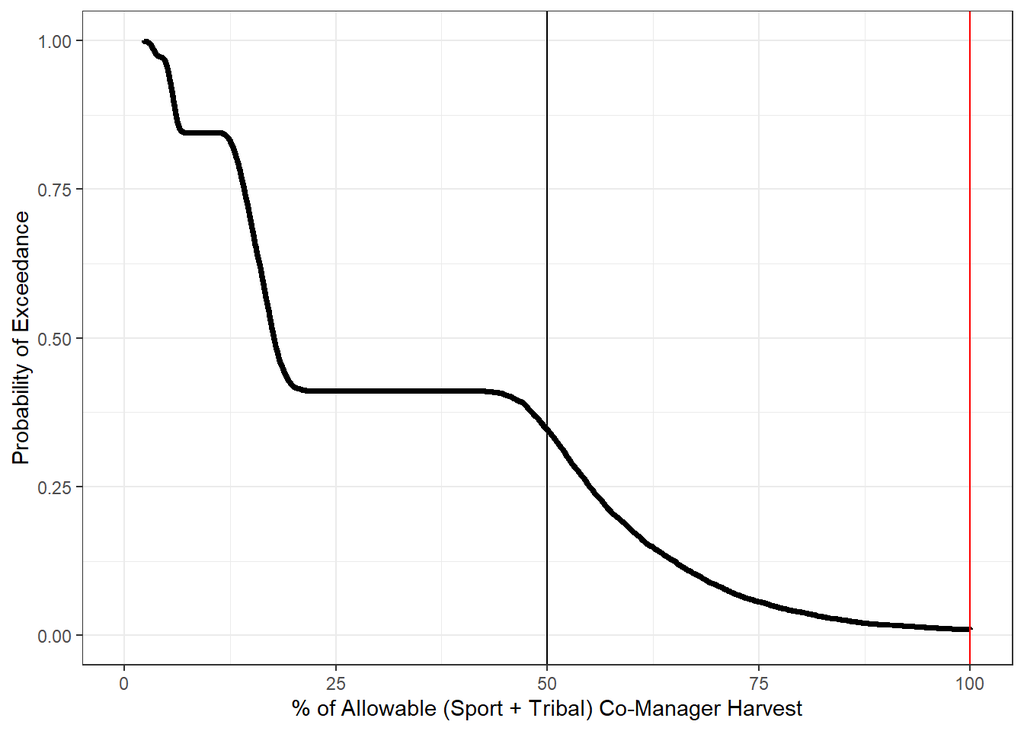

Figure 9. Probability that the actual in-season estimated sport fishery harvest exceeds the allowable harvest (expressed as percentages) under the RMP. Vertical lines denote 50 percent of the allowable harvest, which is shared between the state and tribes, and 100 percent of the allowable harvest. The best in-season estimate of the percent of the allowable harvest that has been used by the sport fishery is located on the graph where the probability of exceedance is 50 percent.

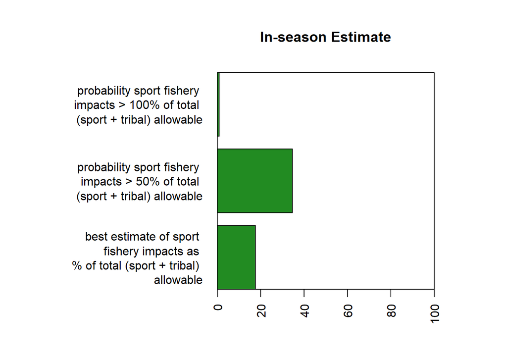

Figure 10. Probability that the sport fishery harvest exceeds 50 and 100 percent of the allowable harvest under the RMP, as well as the best estimate of the percentage of allowable impacts the sport fishery will use.

## Reproducing the Analysis

To run the analysis yourself, you can visit the [**code repository**](https://github.com/tbuehrens/CreelAnalysis/) and follow instructions in this [**R Markdown file**](https://github.com/tbuehrens/CreelAnalysis/blob/main/Skagit_Analysis_2021.Rmd). This file and accompanying repository contain the code necessary to reproduce the entire analysis found on this page as well as the page itself. All analyses require R software [**(install R)**](https://cran.r-project.org/) (v4.0+) for data retrieval, data processing, and summarizing model results, and Stan software [**(install Stan)**](https://github.com/stan-dev/rstan/wiki/RStan-Getting-Started/) parameter estimation. Additionally, for Stan to work, Rtools must also be installed and the C++ toolchain must be configured correctly: [**(install Rtools)**](https://cran.r-project.org/bin/windows/Rtools/).

Page Last Updated: 04/22/2021.